# Vinhos Tintos - Analise Exploratoria

## Analise multivariada

Para a análise multivarida, pegamos as 4 variaveis que contem a correlação com a qualidade. Para melhor visualização, utilizamos a classificação do vinho (sangue de boi, bom, excelente) ao inves de utilizar a nota de 3 a 8.

Plota-se as quatro variaveis, 2 a 2, com a classificação como “wrap”

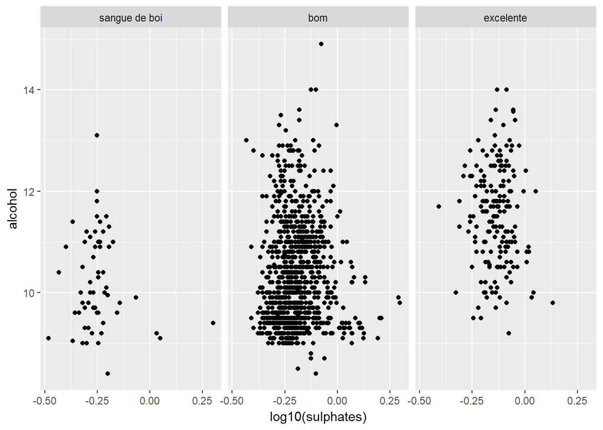

```r
# plotagem do sulfato x alcohol com wrap em classificaçao
ggplot(data = baseVinho,
       aes(x = log10(sulphates),
           y = alcohol)) +
  facet_wrap(~classificacao) +
  geom_point()
```

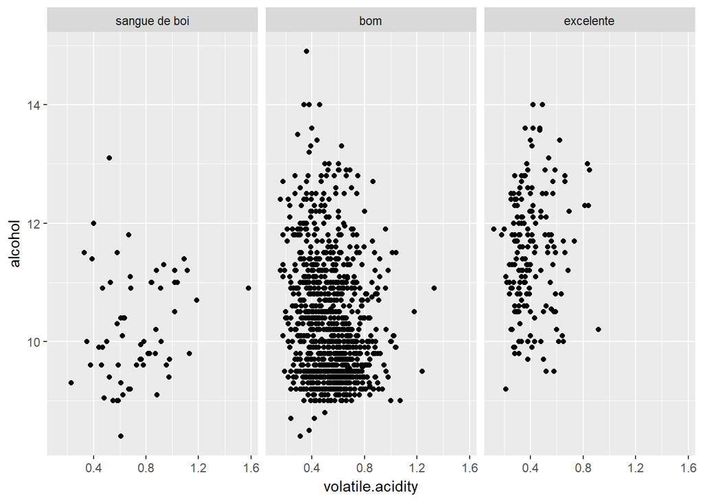

```r
# plotagem do acidez volatil x alcohol com wrap em classificaçao
ggplot(data = baseVinho,
       aes(x = volatile.acidity,
           y = alcohol)) +
  facet_wrap(~classificacao) +
  geom_point()
```

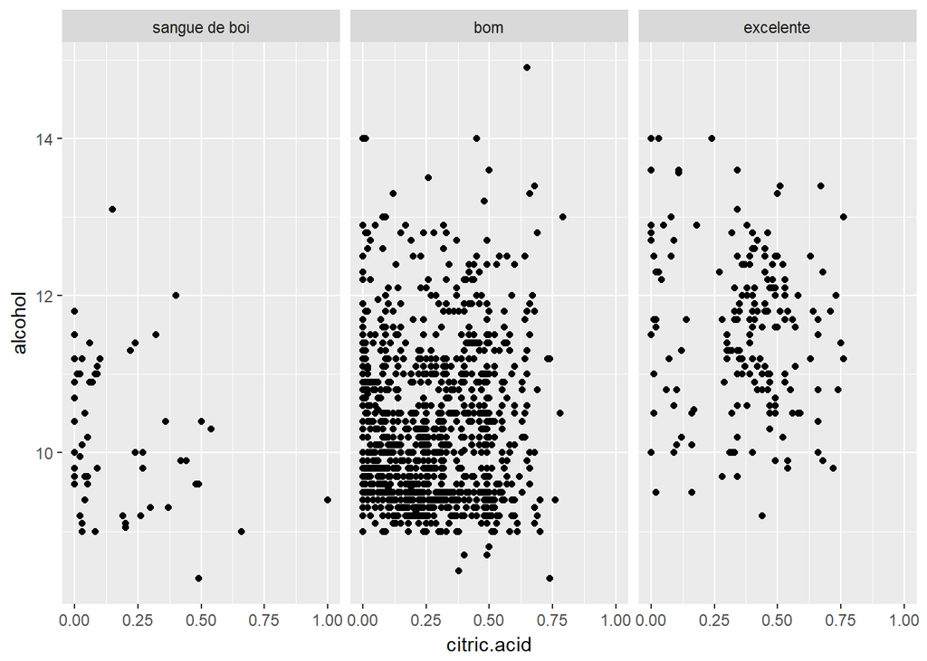

```r
# plotagem do acido citrico x alcool com wrap em classificaçao
ggplot(data = baseVinho,
       aes(x = citric.acid,
           y = alcohol)) +
  facet_wrap(~classificacao) +
  geom_point()
```

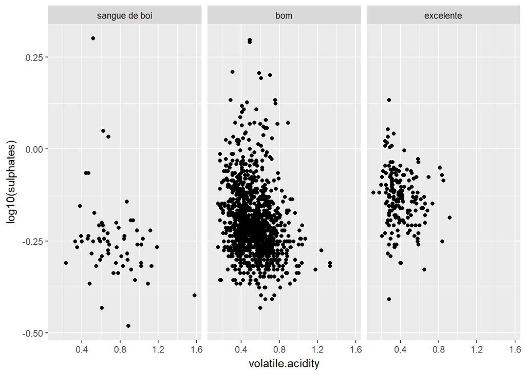

```r
# plotagem do acidez volatil x sulfato(log10) com wrap em classificaçao
ggplot(data = baseVinho,
       aes(x = volatile.acidity,
           y = log10(sulphates))) +
  facet_wrap(~classificacao) +
  geom_point()
```

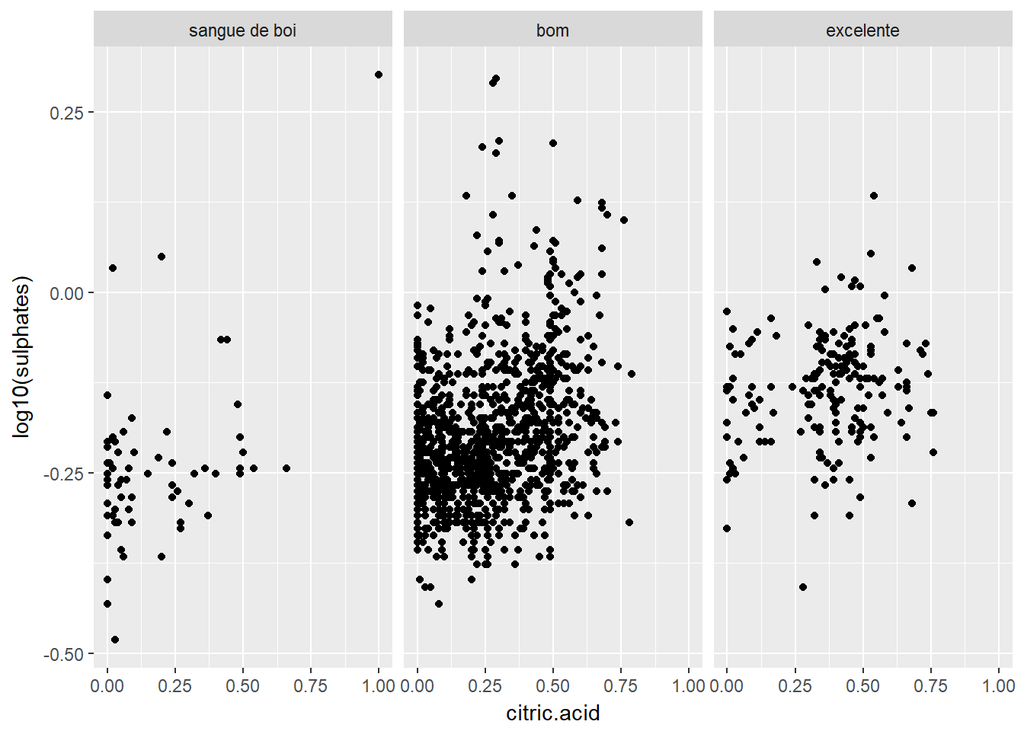

```r
# plotagem do acido citrico x sulfato(log10) com wrap em classificaçao
ggplot(data = baseVinho,
       aes(x = citric.acid,
           y = log10(sulphates))) +
  facet_wrap(~classificacao) +
  geom_point()
```

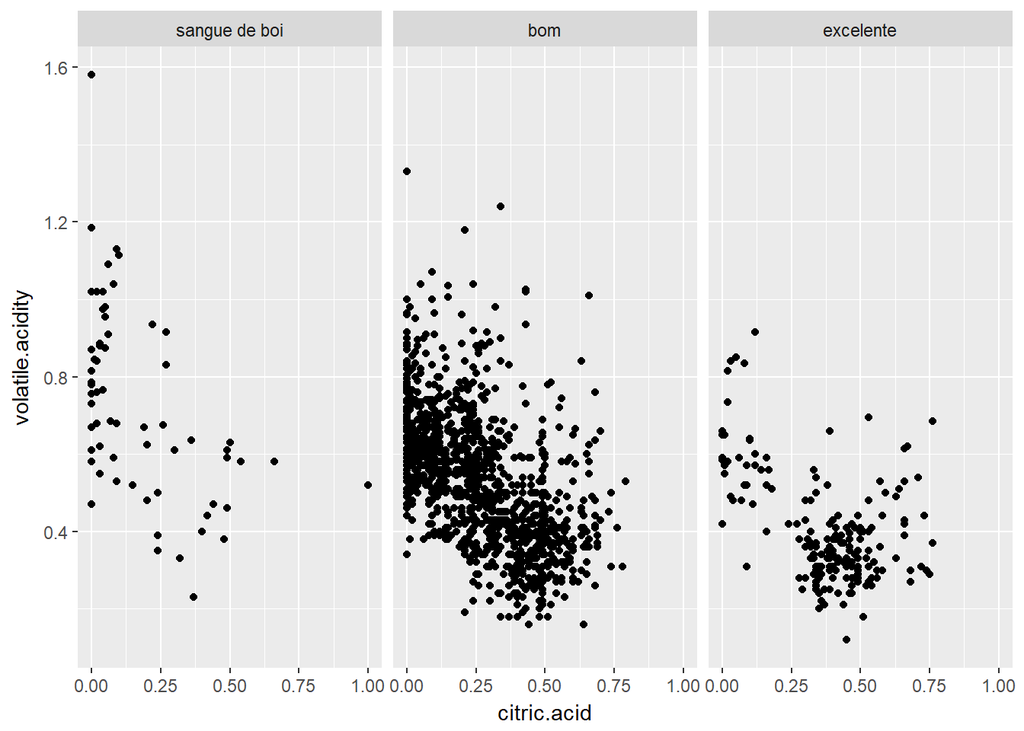

```r
# plotagem do acido citrico x acidez voltail com wrap em classificaçao
ggplot(data = baseVinho,
       aes(x = citric.acid,
           y = volatile.acidity)) +
  facet_wrap(~classificacao) +
  geom_point()
```

Analisando as variaveis em dupla, a que melhor teve uma correlação visivel foi acidez volatil x acidez citrica.

Neste caso, um alto valor de acido citrico (correlacao igual a 0.23) e baixo valor de acido volatil (correlação igual a -0.39) contribuem para a qualidade do vinho. Apesar dos acidos contribuirem diretamente com o PH de qualquer substancia, nesta base, o PH não influenciou na qualidade do vinho (não houve correlação -0.06).

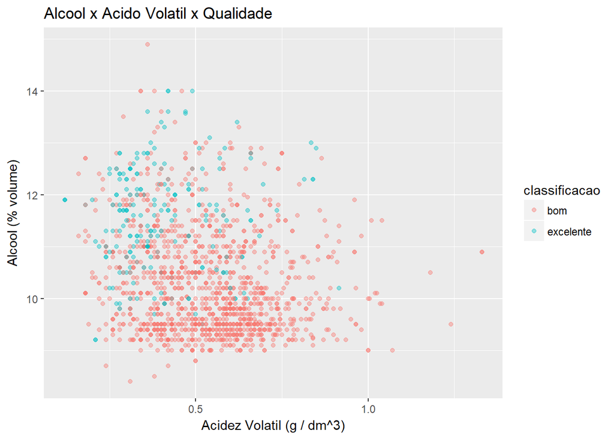

```r
# plotagem do acidez volatil x alcool separando por classificação.
# retiramos os sangue de bois da população
ggplot(data = subset(baseVinho,
                     classificacao != 'sangue de boi'),
       aes(x = volatile.acidity,
           y = alcohol,
           color = classificacao)) +
  geom_point(aes(x = volatile.acidity,
                 y = alcohol,
                 color = classificacao),
                 alpha = 0.4) +
  ggtitle('Alcool x Acido Volatil x Qualidade') +
  xlab('Acidez Volatil (g / dm^3)') +
  ylab('Alcool (% volume)')
```

Ao retirar os sangue de boi da amostragem temos uma relação entre acidez volatil alcool e Qualidade. Altas concentrações de alcool (correlação igual a 0.48) com baixa acidez volatil (correlação igual a -0.39) é uma formula para um excelente vinho.

## Sumario

Concluindo, temos o grafico da relação dos acidos com a qualidade do vinho.

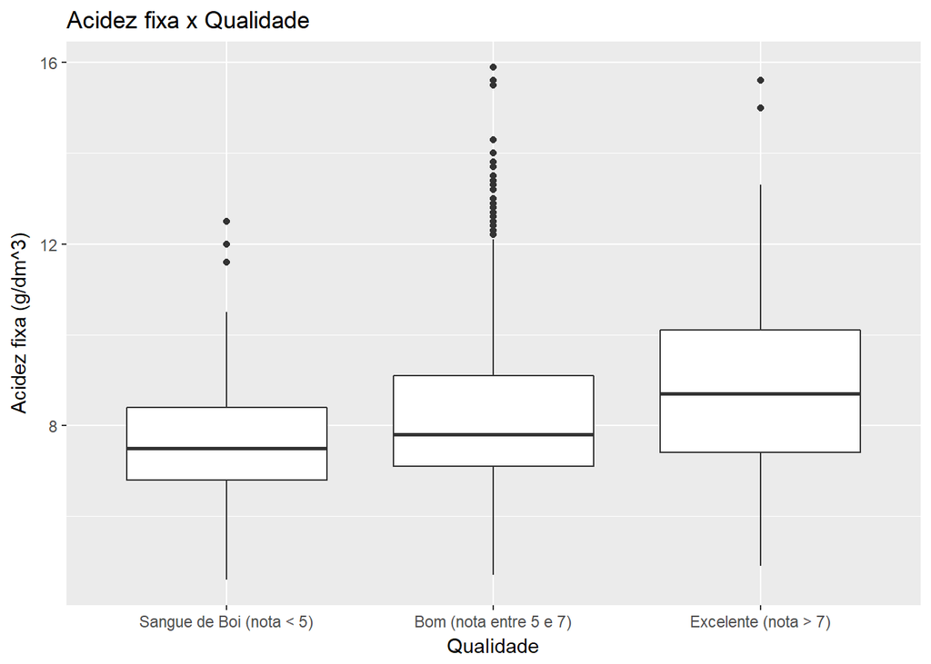

```r
# plotagem do qualidade x acidez fixa separando por classificação
p1 <- ggplot(data = baseVinho) +
  ylab('Acidez fixa (g/dm^3)') +
  xlab('Qualidade') +
  geom_boxplot(aes(x = classificacao,
               y = fixed.acidity)) +
  scale_x_discrete(labels = c("sangue de boi" = "Sangue de Boi (nota < 5)",
                                        "bom" = "Bom (nota entre 5 e 7)",
                                  "excelente" = "Excelente (nota > 7)")) +
  ggtitle('Acidez fixa x Qualidade')

# plotagem do qualidade x acidez volatil separando por classificação
p2 <- ggplot(data = baseVinho) +
  ylab('Acidez Volatil (g/dm^3)') +
  xlab('Qualidade') +
  geom_boxplot( aes(x = classificacao,
               y = volatile.acidity)) +
  scale_x_discrete(labels = c("sangue de boi" = "Sangue de Boi (nota < 5)",
                                        "bom" = "Bom (nota entre 5 e 7)",
                                  "excelente" = "Excelente (nota > 7)")) +
  ggtitle('Acidez Vol. x Qualidade')

# plotagem do qualidade x acidez citrica separando por classificação
p3 <- ggplot(data = baseVinho) +
  ylab('Acido Citrico (g/dm^3)') +
  xlab('Qualidade') +
  geom_boxplot(aes(x = classificacao,
               y = citric.acid)) +
  scale_x_discrete(labels = c("sangue de boi" = "Sangue de Boi (nota < 5)",
                                        "bom" = "Bom (nota entre 5 e 7)",
                                  "excelente" = "Excelente (nota > 7)")) +
  ggtitle('A. Citrico. x Qualidade')

# plotagem do qualidade x PH separando por classificação
p4 <- ggplot(data = baseVinho) +
  ylab('pH') +
  xlab('Quality') +
  geom_boxplot(aes(x = classificacao, y = pH)) +
  scale_x_discrete(labels = c("sangue de boi" = "Sangue de Boi (nota < 5)",
                                        "bom" = "Bom (nota entre 5 e 7)",
                                  "excelente" = "Excelente (nota > 7)")) +
  ggtitle('pH x Qualidade')

p1
```

```r
#grid.arrange(p1, p2, p3, p4)
```

```r
# estatistica dos boxplox
favstats(~baseVinho$fixed.acidity | baseVinho$classificacao, data = baseVinho)
```

```
##   baseVinho$classificacao min  Q1 median   Q3  max     mean       sd    n
## 1           sangue de boi 4.6 6.8    7.5  8.4 12.5 7.871429 1.649284   63
## 2                     bom 4.7 7.1    7.8  9.1 15.9 8.254284 1.682935 1319
## 3               excelente 4.9 7.4    8.7 10.1 15.6 8.847005 1.999977  217
##   missing
## 1       0
## 2       0
## 3       0
```

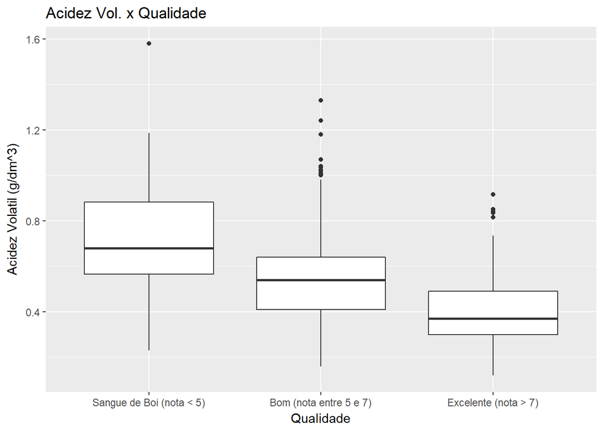

```r
p2
```

```r
# estatistica dos boxplox
favstats(~baseVinho$volatile.acidity | baseVinho$classificacao, data = baseVinho)
```

```
##   baseVinho$classificacao  min    Q1 median     Q3   max      mean
## 1           sangue de boi 0.23 0.565   0.68 0.8825 1.580 0.7242063
## 2                     bom 0.16 0.410   0.54 0.6400 1.330 0.5385595
## 3               excelente 0.12 0.300   0.37 0.4900 0.915 0.4055300
##          sd    n missing
## 1 0.2479695   63       0
## 2 0.1676790 1319       0
## 3 0.1449627  217       0
```

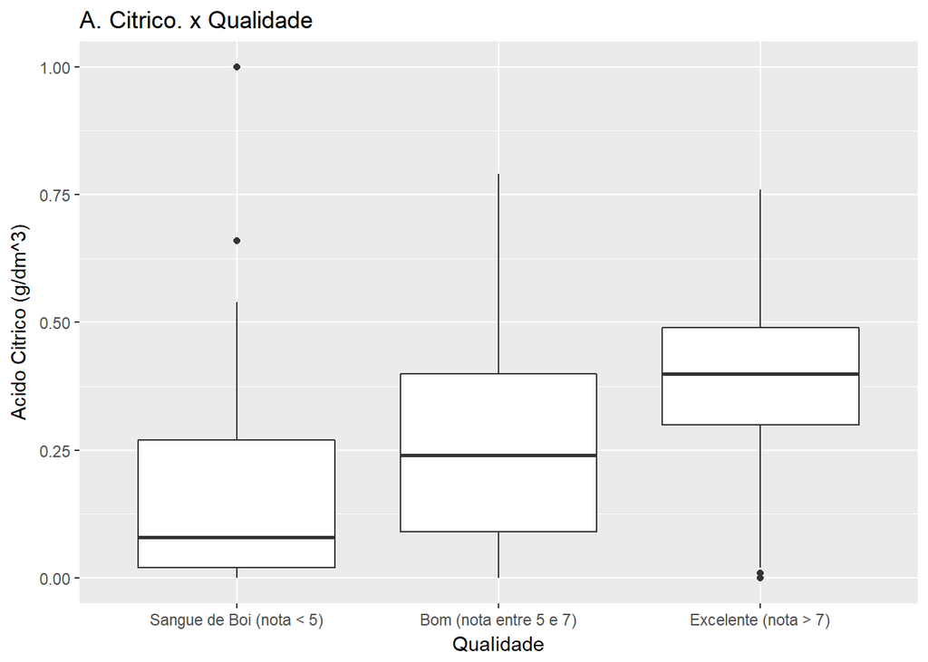

```r
p3
```

```r
# estatistica dos boxplox
favstats(~baseVinho$citric.acid | baseVinho$classificacao, data = baseVinho)
```

```
##   baseVinho$classificacao min   Q1 median   Q3  max      mean        sd
## 1           sangue de boi   0 0.02   0.08 0.27 1.00 0.1736508 0.2074056
## 2                     bom   0 0.09   0.24 0.40 0.79 0.2582638 0.1879946
## 3               excelente   0 0.30   0.40 0.49 0.76 0.3764977 0.1944382
##      n missing
## 1   63       0
## 2 1319       0
## 3  217       0
```

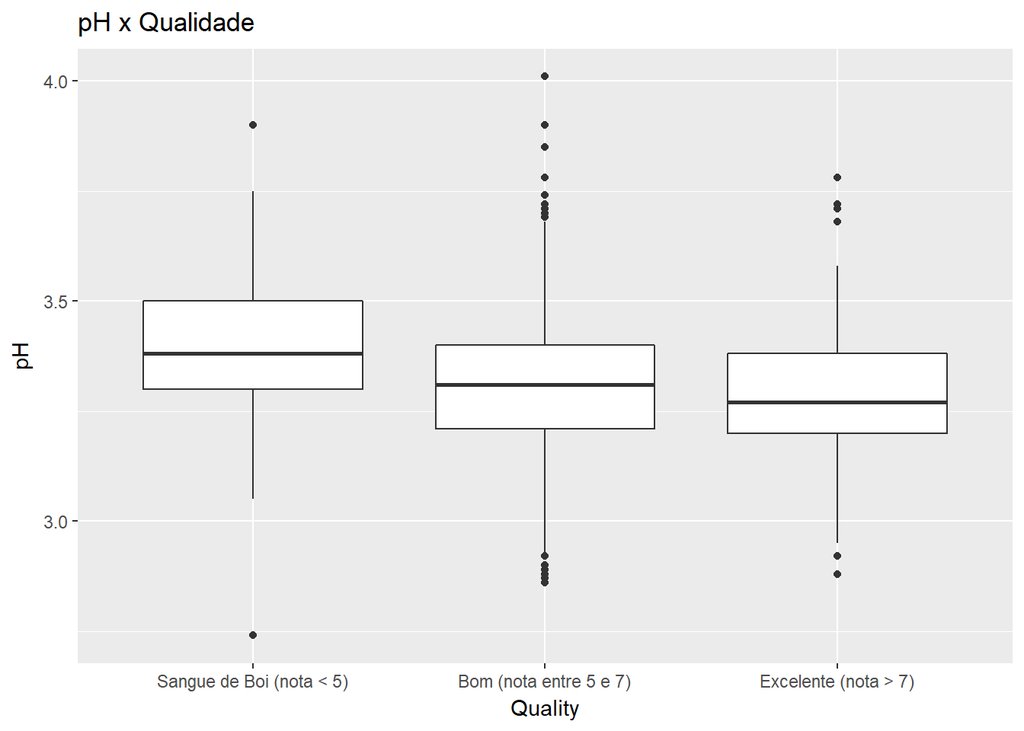

```r
p4
```

```r
# estatistica dos boxplox
favstats(~baseVinho$pH | baseVinho$classificacao, data = baseVinho)
```

```
##   baseVinho$classificacao  min   Q1 median   Q3  max     mean        sd
## 1           sangue de boi 2.74 3.30   3.38 3.50 3.90 3.384127 0.1751003
## 2                     bom 2.86 3.21   3.31 3.40 4.01 3.311296 0.1523446
## 3               excelente 2.88 3.20   3.27 3.38 3.78 3.288802 0.1544777
##      n missing
## 1   63       0
## 2 1319       0
## 3  217       0
```

ESses graficos mostram o efeito dos acidos na qualidade do vinho. Verificamos que os vinhos excelentes possuem maior acidez fixa (media = 8.84), apesar de ter alguns outliers do sangue de boi e do bom vinho com acidez fixa próxima dos excelentes. A maior presença de acido volatil torna o vinho mais próximo ao sangue de boi (correlação -0.39). Acido Citrico tem uma boa correlação positiva com a qualidade (0.23). Quanto menor o PH mais acido é o vinho, nota-se pelo boxplot que os “sangue de boi” possui um maior PH, porem com uma correlação muito baixa (-0.06), como vimos na analise univariada.

### Correlação do Alcool com qualidade do vinho

Já era de se imaginar que o alcool faz toda a diferença em um vinho. É a variável que contem a maior correlação com a qualidade do vinho.

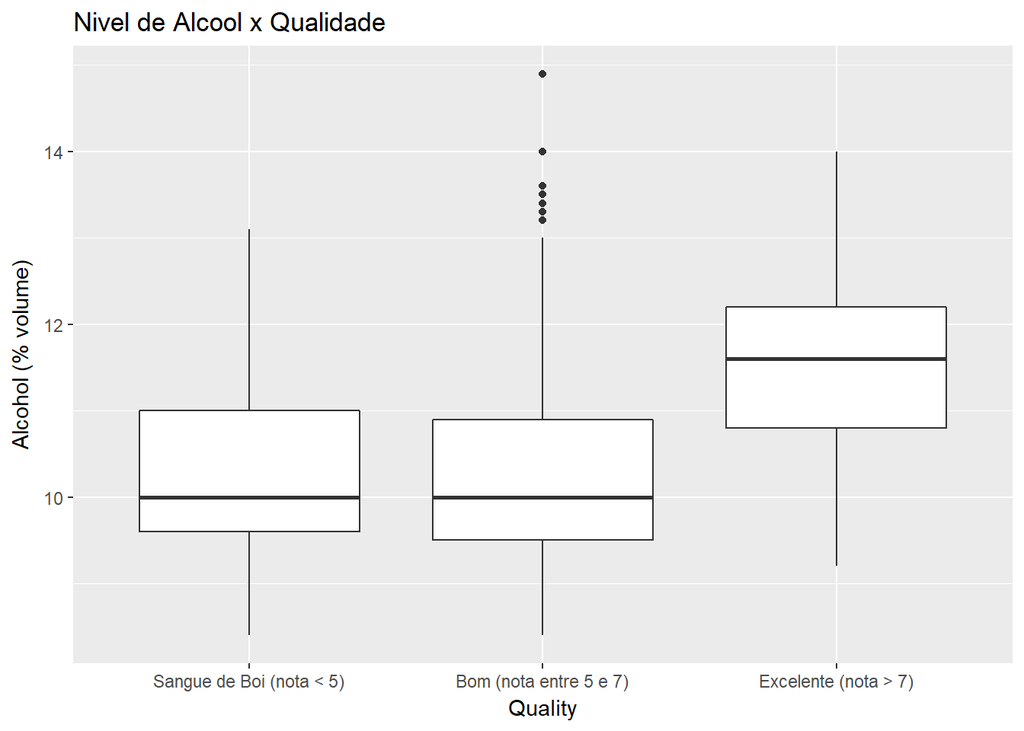

```r
# plotagem do qualidade x alcool separando por classificação
ggplot(data = baseVinho) +
  geom_boxplot(aes(x = classificacao,
           y = alcohol)) +
  scale_x_discrete(labels = c("sangue de boi" = "Sangue de Boi (nota < 5)",
                                        "bom" = "Bom (nota entre 5 e 7)",
                                  "excelente" = "Excelente (nota > 7)")) +
  ggtitle('Nivel de Alcool x Qualidade') +
  xlab('Quality') +
  ylab('Alcohol (% volume)')
```

```r
# estatistica dos boxplox
favstats(~baseVinho$alcohol | baseVinho$classificacao, data = baseVinho)
```

```
##   baseVinho$classificacao min   Q1 median   Q3  max     mean        sd
## 1           sangue de boi 8.4  9.6   10.0 11.0 13.1 10.21587 0.9181778
## 2                     bom 8.4  9.5   10.0 10.9 14.9 10.25272 0.9723537
## 3               excelente 9.2 10.8   11.6 12.2 14.0 11.51805 0.9981532
##      n missing
## 1   63       0
## 2 1319       0
## 3  217       0
```

Apesar do gráfico mostrar que os vinhos com classificação “excelente” possuem maior concentração de alcool (média = 11.51), verificando o intervalo da amostra e os outliers de cada categoria, mostra-se que o alcool por si só nao qualifica o vinho como de boa qualidade.

### E o que realmente importa, para se ter um excelente vinho?

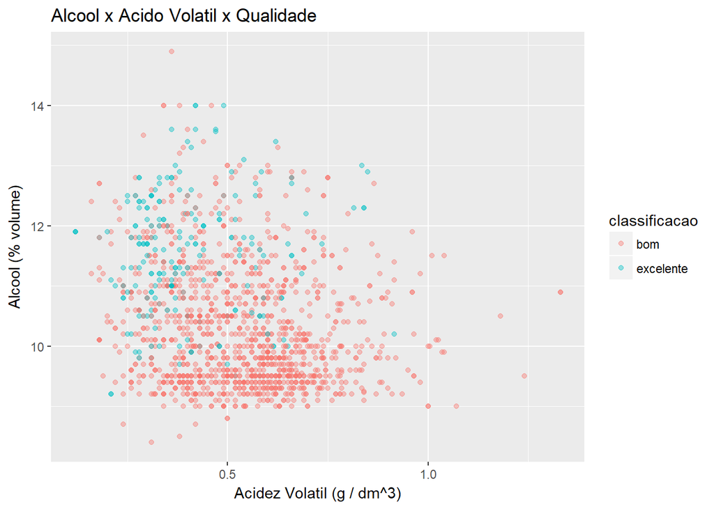

```r
# plotagem do acidez volatil x alcool separando por classificação.
# retiramos os sangue de bois da população
ggplot(data = subset(baseVinho,
                     classificacao != 'sangue de boi'),
       aes(x = volatile.acidity,
           y = alcohol,
           color = classificacao)) +
  geom_point(aes(x = volatile.acidity,
                 y = alcohol,
                 color = classificacao),
                 alpha = 0.4) +
  ggtitle('Alcool x Acido Volatil x Qualidade') +
  xlab('Acidez Volatil (g / dm^3)') +
  ylab('Alcool (% volume)')
```

## Conclusão

Após esta análise exploratórias dos dados destes vinhos, identificamos as principais caracteristicas quimicas que determina a qualidade do vinho desta amostragem. Das principais correlações podemos citar: alcool, sulfato e a acidez. Uma das limitações desta análise, destaca-se a nota da qualidade, uma vez que foi feita por método subjetivo dos diferentes avaliadores que compoe a população. As dificuldades do estudo foi analisar via gráfico se a variavel é normal ou não. Devia-se utilizar testes como o Kolmogorov-Smirnoff para verificar o quao normal é a variável. Outra dificuldade, é até quando um valor de correlação realmente influencia na qualidade de um vinho. Talvez o número de outliers se deve à forma subjetiva de análise da qualidade do vinho. O sucesso do estudo foi saber identificar rapidamente as correlações entre as variaveis e as possiveis correlações que elas podem ter com a qualidade do vinho.

O que realmente supreendeu, foi a acidez ter correlação alta e o PH não ter nenhuma correlação (cor = -0.06) com a qualidade do vinho, uma vez que quimicamente, o PH é diretamente influenciado pelos acidos contidos em uma amostra. Para uma melhoria no futuro, recomenda-se comparar difentes marcas de vinho, para que certificar que os compontes quimicos encontrados neste estudo realmente influencia na qualidade dos vinhos em geral.